# Distribution of tuberculosis-like lesions in wild boar

In this activity, you will practice fitting a generalized linear model. The data are from Vicente *et al* (2006), who analysed the distribution of tuberculosis-like lesions in wild boar, *Sus scrofa*. Part of this study was looking at the potential importance of wild board in maintaining tuberculosis in south central Spain.

Before we being, let’s load some packages

```r
library("janitor")
library("dplyr")
library("tibble")
library("tidyr")
library("readr")
library("ggplot2")
library("gglm")
library("performance")
library("marginaleffects")
```

Now we can load the data

```r
wb <- read_table("data/boar.txt", col_types = "dddd") |>
  janitor::clean_names()
```

There are four variables in the data set:

- `tb` and indicator of the presence (`1`) or absence (`0`) of tuberculoisis-like lesions,
- `sex` coded as `1` or `2`,
- `age_class`, and
- `length_ct`, which is the length of the animal’s head and body.

We should recode some of these variables if we intended to use `sex` and `age_class` in models as these are categorical variables and are best coded as factors in R. For plotting it can also be useful to do this:

```r
wb <- wb |>
  mutate(
    f_tb = factor(tb, levels = c(0,1))
  )
```

Start by producing boxplots of `length_ct` against `tb` presence and absence

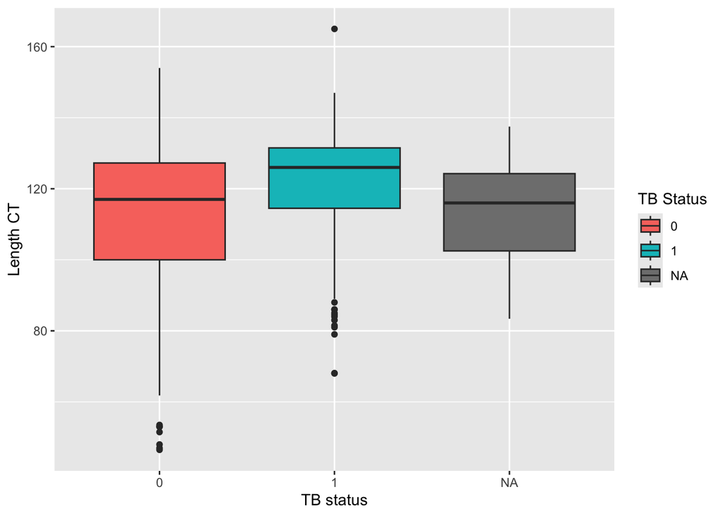

```r
wb |>
  ggplot(
    aes(
      y = length_ct, x = f_tb, fill = f_tb
    )
  ) +
  geom_boxplot() +
  labs(
    x = "TB status",
    fill = "TB Status",
    y = "Length CT"
  )
```

There is a tendency, in the data for animals with tubercolosis-like lesions to be larger. Of course, in any real data analysis, we should investigate why there are missing values in the `tb` variable and account for potential missing data problems.

**NoteQuestion**

However, for now, let’s proceed by fitting a simple binomial GLM to these data. The model we want to fit is

$$\begin{align*}
\mathtt{tb}_i \sim& \mathcal{B}(\mu_i, 1) \\
\mathbb{E}(\mathtt{tb}_i) =& \mu_i \\
\text{logit}(\mu_i) =& \beta_0 + \beta_1 \mathtt{length\_ct}
\end{align*}$$

The response variable is `tb` (or `f_tb` can be used), and the predictor variable is `length_ct`. Fit this model in R.

**TipAnswer**

```r
wb_glm <- glm(
  tb ~ length_ct,
  data = wb,
  family = binomial(link = "logit")
)
```

**NoteQuestion**

Produce the model summary. Is the effect of `length_ct` on the prevalence of tuberculosis-like lesions statistically interesting?

**TipAnswer**

```r
summary(wb_glm)
```

```
Call:
glm(formula = tb ~ length_ct, family = binomial(link = "logit"),
    data = wb)

Coefficients:
             Estimate Std. Error z value Pr(>|z|)
(Intercept) -3.892109   0.671152  -5.799 6.67e-09 ***
length_ct    0.031606   0.005588   5.656 1.55e-08 ***
---
Signif. codes:  0 '***' 0.001 '**' 0.01 '*' 0.05 '.' 0.1 ' ' 1

(Dispersion parameter for binomial family taken to be 1)

    Null deviance: 700.76  on 507  degrees of freedom
Residual deviance: 663.56  on 506  degrees of freedom
  (149 observations deleted due to missingness)
AIC: 667.56

Number of Fisher Scoring iterations: 4
```

Yes, the effect is statistically interesting; the *p* values is small.

Having fitted a model, it is often useful to plot estimates from the model at representative values of the covariates. The *marginaleffects* package makes this easy and forces us to condition on specific values of the variables in more complex situations.

Here, we just prepare a plot of the fitted model `wb_glm` using `plot_predictions()`:

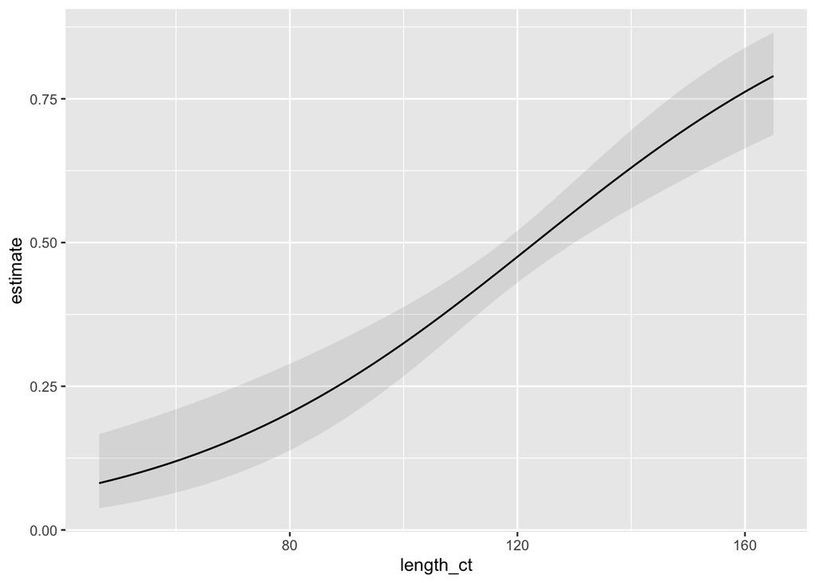

```r
wb_glm |> plot_predictions(condition = "length_ct")
```

We can add the original data to this plot, as a point layer

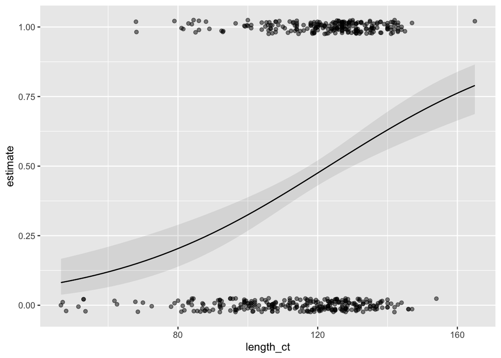

```r
wb_glm |> plot_predictions(condition = "length_ct") +
  geom_point(
    data = wb,
    aes(x = length_ct, y = tb),
    position = position_jitter(height = 0.025),
    alpha = 0.5
  )
```

**NoteQuestion**

Look at the model diagnostics. Are there any potential problems with the model?

**TipAnswer**

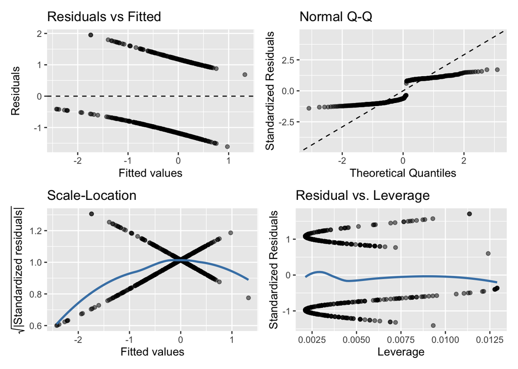

```r
gglm(wb_glm)
```

Err…

That was a trick question; model diagnostics are notoriously difficult for binary responses. Better diagnostics can be achieved using the *performance* package and it’s `check_model()` function:

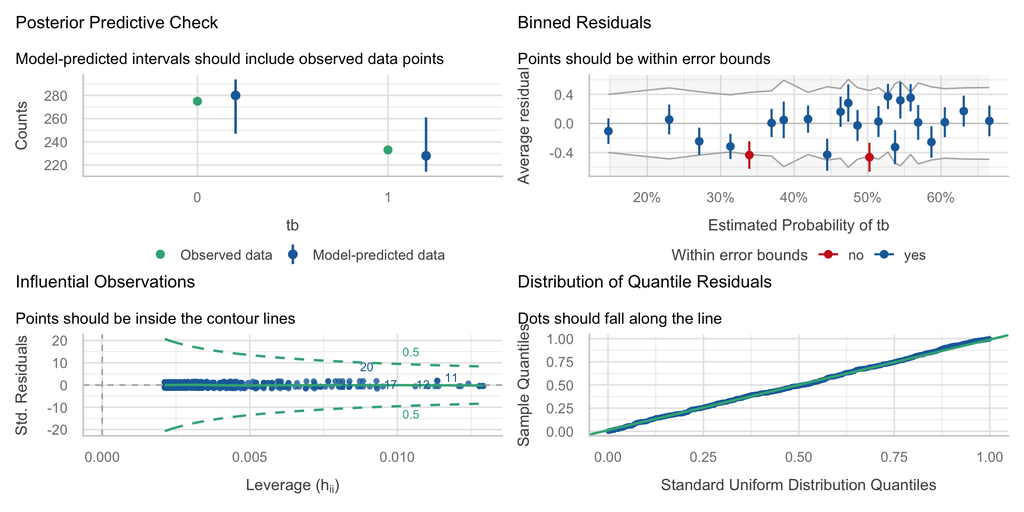

```r
check_model(wb_glm)
```

Read `?check_model` to understand what the different diagnostics produced here show and how to interpret them. Note that these plots are using simulated quantile residuals from DHARMa, which are essential for binary data.